# Session 2: Homework 1

Group 29

2020-09-27

# 1 Where Do People Drink The Most Beer, Wine And Spirits?

Back in 2014, [fivethiryeight.com](https://fivethirtyeight.com/features/dear-mona-followup-where-do-people-drink-the-most-beer-wine-and-spirits/) published an article on alchohol consumption in different countries. The data `drinks` is available as part of the `fivethirtyeight` package. Make sure you have installed the `fivethirtyeight` package before proceeding.

```r
library(fivethirtyeight)
data(drinks)


# or download directly
# alcohol_direct <- read_csv("https://raw.githubusercontent.com/fivethirtyeight/data/master/alcohol-consumption/drinks.csv")
```

What are the variable types? Any missing values we should worry about?

- There are 1 character (country) and 4 numeric variables (beer_servings, spirit_servings, wine_servings, total_litres_of_pure_alcohol). We don’t have any missing data, they are all complete.

```r
data(drinks)
skim(drinks)
```

Data summary

| Name | drinks |
| --- | --- |
| Number of rows | 193 |
| Number of columns | 5 |
| _______________________ |  |
| Column type frequency: |  |
| character | 1 |
| numeric | 4 |
| ________________________ |  |
| Group variables | None |

**Variable type: character**

| skim_variable | n_missing | complete_rate | min | max | empty | n_unique | whitespace |
| --- | --- | --- | --- | --- | --- | --- | --- |
| country | 0 | 1 | 3 | 28 | 0 | 193 | 0 |

**Variable type: numeric**

| skim_variable | n_missing | complete_rate | mean | sd | p0 | p25 | p50 | p75 | p100 | hist |
| --- | --- | --- | --- | --- | --- | --- | --- | --- | --- | --- |
| beer_servings | 0 | 1 | 106.16 | 101.14 | 0 | 20.0 | 76.0 | 188.0 | 376.0 | ▇▃▂▂▁ |
| spirit_servings | 0 | 1 | 80.99 | 88.28 | 0 | 4.0 | 56.0 | 128.0 | 438.0 | ▇▃▂▁▁ |
| wine_servings | 0 | 1 | 49.45 | 79.70 | 0 | 1.0 | 8.0 | 59.0 | 370.0 | ▇▁▁▁▁ |
| total_litres_of_pure_alcohol | 0 | 1 | 4.72 | 3.77 | 0 | 1.3 | 4.2 | 7.2 | 14.4 | ▇▃▅▃▁ |

```r
# No missing values!
```

Make a plot that shows the top 25 beer consuming countries

```r
beer_data<-drinks %>%
  arrange(desc(beer_servings)) %>%
  slice(1:25)

beer_data
```

```
## # A tibble: 25 x 5
##    country     beer_servings spirit_servings wine_servings total_litres_of_pure~
##    <chr>               <int>           <int>         <int>                 <dbl>
##  1 Namibia               376               3             1                   6.8
##  2 Czech Repu~           361             170           134                  11.8
##  3 Gabon                 347              98            59                   8.9
##  4 Germany               346             117           175                  11.3
##  5 Lithuania             343             244            56                  12.9
##  6 Poland                343             215            56                  10.9
##  7 Venezuela             333             100             3                   7.7
##  8 Ireland               313             118           165                  11.4
##  9 Palau                 306              63            23                   6.9
## 10 Romania               297             122           167                  10.4
## # ... with 15 more rows
```

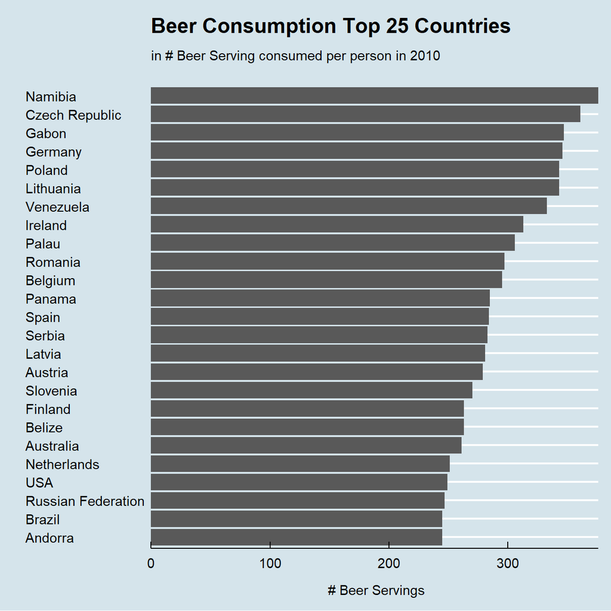

```r
ggplot(beer_data, aes(y=reorder(country,beer_servings),x=beer_servings))+
  geom_col() +
  theme_economist() +
  labs(title="Beer Consumption Top 25 Countries", subtitle= "\nin # Beer Serving consumed per person in 2010\n", y="", x="\n # Beer Servings") +
  scale_x_continuous(expand = c(0,0))
```

Make a plot that shows the top 25 wine consuming countries

```r
wine_data <- drinks %>%
  arrange(desc(wine_servings))%>%
  slice(1:25)

wine_data
```

```
## # A tibble: 25 x 5
##    country      beer_servings spirit_servings wine_servings total_litres_of_pur~
##    <chr>                <int>           <int>         <int>                <dbl>
##  1 France                 127             151           370                 11.8
##  2 Portugal               194              67           339                 11
##  3 Andorra                245             138           312                 12.4
##  4 Switzerland            185             100           280                 10.2
##  5 Denmark                224              81           278                 10.4
##  6 Slovenia               270              51           276                 10.6
##  7 Luxembourg             236             133           271                 11.4
##  8 Croatia                230              87           254                 10.2
##  9 Italy                   85              42           237                  6.5
## 10 Equatorial ~            92               0           233                  5.8
## # ... with 15 more rows
```

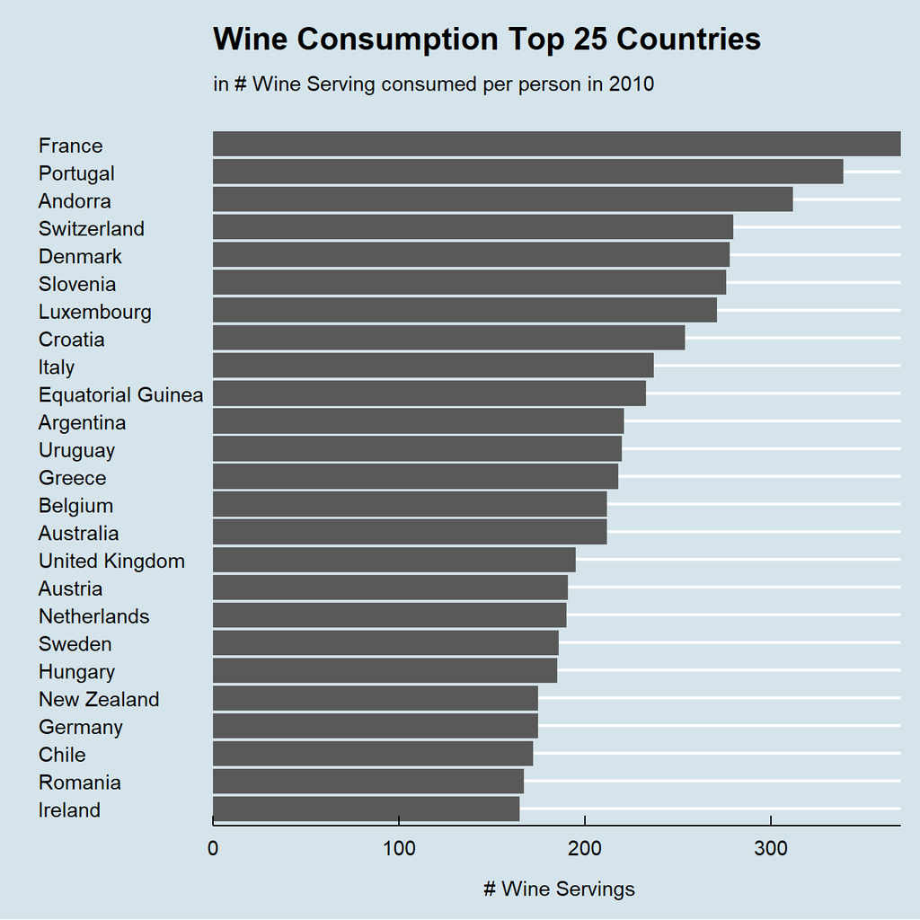

```r
ggplot(wine_data, aes(y=reorder(country,wine_servings),x=wine_servings))+
  geom_col() +
  theme_economist() +
  labs(title="Wine Consumption Top 25 Countries", subtitle= "\nin # Wine Serving consumed per person in 2010\n", y="", x="\n # Wine Servings") +
  scale_x_continuous(expand = c(0,0))
```

Finally, make a plot that shows the top 25 spirit consuming countries

```r
spirit_data <- drinks %>%
  arrange(desc(spirit_servings))%>%
  slice(1:25)

spirit_data
```

```
## # A tibble: 25 x 5
##    country      beer_servings spirit_servings wine_servings total_litres_of_pur~
##    <chr>                <int>           <int>         <int>                <dbl>
##  1 Grenada                199             438            28                 11.9
##  2 Belarus                142             373            42                 14.4
##  3 Haiti                    1             326             1                  5.9
##  4 Russian Fed~           247             326            73                 11.5
##  5 St. Lucia              171             315            71                 10.1
##  6 Guyana                  93             302             1                  7.1
##  7 Slovakia               196             293           116                 11.4
##  8 Dominica                52             286            26                  6.6
##  9 Thailand                99             258             1                  6.4
## 10 Cook Islands             0             254            74                  5.9
## # ... with 15 more rows
```

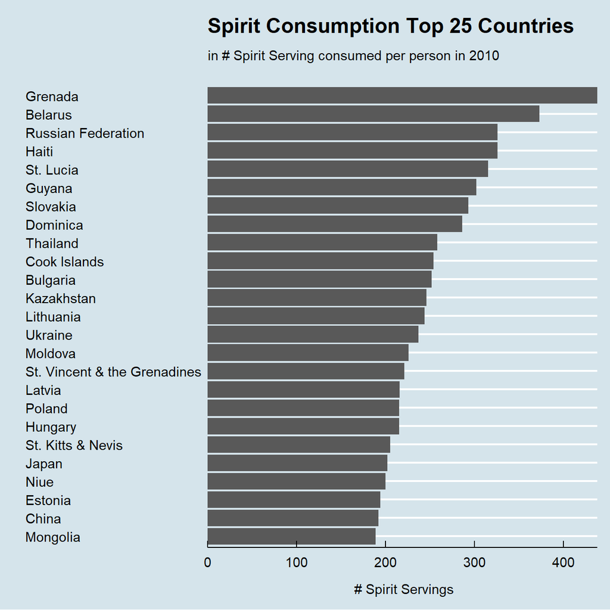

```r
ggplot(spirit_data, aes(y=reorder(country,spirit_servings),x=spirit_servings))+
  geom_col() +
  theme_economist() +
  labs(title="Spirit Consumption Top 25 Countries", subtitle= "\nin # Spirit Serving consumed per person in 2010\n", y="", x="\n # Spirit Servings") +
  scale_x_continuous(expand = c(0,0))
```

What can you infer from these plots? Don’t just explain what’s in the graph, but speculate or tell a short story (1-2 paragraphs max).

# 2 Analysis of movies- IMDB dataset

We will look at a subset sample of movies, taken from the [Kaggle IMDB 5000 movie dataset](https://www.kaggle.com/carolzhangdc/imdb-5000-movie-dataset)

```r
movies <- vroom::vroom("movies.csv")
glimpse(movies)
```

[output not shown]

Besides the obvious variables of `title`, `genre`, `director`, `year`, and `duration`, the rest of the variables are as follows:

- `gross` : The gross earnings in the US box office, not adjusted for inflation
- `budget`: The movie’s budget
- `cast_facebook_likes`: the number of facebook likes cast memebrs received
- `votes`: the number of people who voted for (or rated) the movie in IMDB
- `reviews`: the number of reviews for that movie
- `rating`: IMDB average rating

## 2.1 Use your data import, inspection, and cleaning skills to answer the following:

- Are there any missing values (NAs)? Are all entries distinct or are there duplicate entries?

```r
movies <- vroom::vroom("movies.csv")
skim(movies)
```

Data summary

| Name | movies |
| --- | --- |
| Number of rows | 2961 |
| Number of columns | 11 |
| _______________________ |  |
| Column type frequency: |  |
| character | 3 |
| numeric | 8 |
| ________________________ |  |
| Group variables | None |

**Variable type: character**

| skim_variable | n_missing | complete_rate | min | max | empty | n_unique | whitespace |
| --- | --- | --- | --- | --- | --- | --- | --- |
| title | 0 | 1 | 1 | 83 | 0 | 2907 | 0 |
| genre | 0 | 1 | 5 | 11 | 0 | 17 | 0 |
| director | 0 | 1 | 3 | 32 | 0 | 1366 | 0 |

**Variable type: numeric**

| skim_variable | n_missing | complete_rate | mean | sd | p0 | p25 | p50 | p75 | p100 | hist |
| --- | --- | --- | --- | --- | --- | --- | --- | --- | --- | --- |
| year | 0 | 1 | 2.00e+03 | 9.95e+00 | 1920.0 | 2.00e+03 | 2.00e+03 | 2.01e+03 | 2.02e+03 | ▁▁▁▂▇ |
| duration | 0 | 1 | 1.10e+02 | 2.22e+01 | 37.0 | 9.50e+01 | 1.06e+02 | 1.19e+02 | 3.30e+02 | ▃▇▁▁▁ |
| gross | 0 | 1 | 5.81e+07 | 7.25e+07 | 703.0 | 1.23e+07 | 3.47e+07 | 7.56e+07 | 7.61e+08 | ▇▁▁▁▁ |
| budget | 0 | 1 | 4.06e+07 | 4.37e+07 | 218.0 | 1.10e+07 | 2.60e+07 | 5.50e+07 | 3.00e+08 | ▇▂▁▁▁ |
| cast_facebook_likes | 0 | 1 | 1.24e+04 | 2.05e+04 | 0.0 | 2.24e+03 | 4.60e+03 | 1.69e+04 | 6.57e+05 | ▇▁▁▁▁ |
| votes | 0 | 1 | 1.09e+05 | 1.58e+05 | 5.0 | 1.99e+04 | 5.57e+04 | 1.33e+05 | 1.69e+06 | ▇▁▁▁▁ |
| reviews | 0 | 1 | 5.03e+02 | 4.94e+02 | 2.0 | 1.99e+02 | 3.64e+02 | 6.31e+02 | 5.31e+03 | ▇▁▁▁▁ |
| rating | 0 | 1 | 6.39e+00 | 1.05e+00 | 1.6 | 5.80e+00 | 6.50e+00 | 7.10e+00 | 9.30e+00 | ▁▁▆▇▁ |

```r
sum(duplicated(movies))
```

```
## [1] 0
```

- Produce a table with the count of movies by genre, ranked in descending order

```r
 movies %>%
    group_by(genre) %>%
    count(sort=TRUE)
```

```
## # A tibble: 17 x 2
## # Groups:   genre [17]
##    genre           n
##    <chr>       <int>
##  1 Comedy        848
##  2 Action        738
##  3 Drama         498
##  4 Adventure     288
##  5 Crime         202
##  6 Biography     135
##  7 Horror        131
##  8 Animation      35
##  9 Fantasy        28
## 10 Documentary    25
## 11 Mystery        16
## 12 Sci-Fi          7
## 13 Family          3
## 14 Musical         2
## 15 Romance         2
## 16 Western         2
## 17 Thriller        1
```

- Produce a table with the average gross earning and budget (`gross` and `budget`) by genre. Calculate a variable `return_on_budget` which shows how many $ did a movie make at the box office for each $ of its budget. Ranked genres by this `return_on_budget` in descending order

```r
movies_genre<- movies %>%
  group_by(genre) %>%
  summarize(avg_gross=mean(gross),avg_budget=mean(budget)) %>%
  mutate(return_on_budget=avg_gross-avg_budget) %>%
  arrange(desc(return_on_budget))

movies_genre
```

```
## # A tibble: 17 x 4
##    genre        avg_gross avg_budget return_on_budget
##    <chr>            <dbl>      <dbl>            <dbl>
##  1 Family      149160478.  14833333.       134327144.
##  2 Musical      92084000    3189500         88894500
##  3 Animation    98433792.  61701429.        36732364.
##  4 Adventure    95794257.  66290069.        29504188.
##  5 Mystery      67533021.  39218750         28314271.
##  6 Fantasy      42408841.  17582143.        24826698.
##  7 Horror       37713738.  13504916.        24208821.
##  8 Comedy       42630552.  24446319.        18184233.
##  9 Western      20821884    3465000         17356884
## 10 Biography    45201805.  28543696.        16658109.
## 11 Action       86583860.  71354888.        15228973.
## 12 Documentary  17353973.   5887852.        11466121
## 13 Drama        37465371.  26242933.        11222438.
## 14 Crime        37502397.  26596169.        10906228.
## 15 Romance      31264848.  25107500          6157348.
## 16 Sci-Fi       29788371.  27607143.         2181228
## 17 Thriller         2468     300000          -297532
```

- Produce a table that shows the top 15 directors who have created the highest gross revenue in the box office. Don’t just show the total gross amount, but also the mean, median, and standard deviation per director.

```r
movies_director<-movies %>%
  group_by(director) %>%
  summarize(total=sum(gross),mean=mean(gross),median=median(gross),sd=sd(gross)) %>%
  arrange(desc(total)) %>%
  head(15)

movies_director
```

```
## # A tibble: 15 x 5
##    director               total       mean     median         sd
##    <chr>                  <dbl>      <dbl>      <dbl>      <dbl>
##  1 Steven Spielberg  4014061704 174524422. 164435221  101421051.
##  2 Michael Bay       2231242537 171634041. 138396624  127161579.
##  3 Tim Burton        2071275480 129454718.  76519172  108726924.
##  4 Sam Raimi         2014600898 201460090. 234903076  162126632.
##  5 James Cameron     1909725910 318287652. 175562880. 309171337.
##  6 Christopher Nolan 1813227576 226653447  196667606. 187224133.
##  7 George Lucas      1741418480 348283696  380262555  146193880.
##  8 Robert Zemeckis   1619309108 124562239. 100853835   91300279.
##  9 Clint Eastwood    1378321100  72543216.  46700000   75487408.
## 10 Francis Lawrence  1358501971 271700394. 281666058  135437020.
## 11 Ron Howard        1335988092 111332341  101587923   81933761.
## 12 Gore Verbinski    1329600995 189942999. 123207194  154473822.
## 13 Andrew Adamson    1137446920 284361730  279680930. 120895765.
## 14 Shawn Levy        1129750988 102704635.  85463309   65484773.
## 15 Ridley Scott      1128857598  80632686.  47775715   68812285.
```

- Finally, ratings. Produce a table that describes how ratings are distributed by genre. We don’t want just the mean, but also, min, max, median, SD and some kind of a histogram or density graph that visually shows how ratings are distributed.

```r
movies_rating<-movies %>%
  group_by(genre) %>%
  summarize(mean=mean(rating),min=min(rating),max=max(rating),median=median(rating),sd=sd(rating))
movies_rating
```

```
## # A tibble: 17 x 6
##    genre        mean   min   max median     sd
##    <chr>       <dbl> <dbl> <dbl>  <dbl>  <dbl>
##  1 Action       6.23   2.1   9     6.3   1.03
##  2 Adventure    6.51   2.3   8.6   6.6   1.09
##  3 Animation    6.65   4.5   8     6.9   0.968
##  4 Biography    7.11   4.5   8.9   7.2   0.760
##  5 Comedy       6.11   1.9   8.8   6.2   1.02
##  6 Crime        6.92   4.8   9.3   6.9   0.849
##  7 Documentary  6.66   1.6   8.5   7.4   1.77
##  8 Drama        6.73   2.1   8.8   6.8   0.917
##  9 Family       6.5    5.7   7.9   5.9   1.22
## 10 Fantasy      6.15   4.3   7.9   6.45  0.959
## 11 Horror       5.83   3.6   8.5   5.9   1.01
## 12 Musical      6.75   6.3   7.2   6.75  0.636
## 13 Mystery      6.86   4.6   8.5   6.9   0.882
## 14 Romance      6.65   6.2   7.1   6.65  0.636
## 15 Sci-Fi       6.66   5     8.2   6.4   1.09
## 16 Thriller     4.8    4.8   4.8   4.8  NA
## 17 Western      5.70   4.1   7.3   5.70  2.26
```

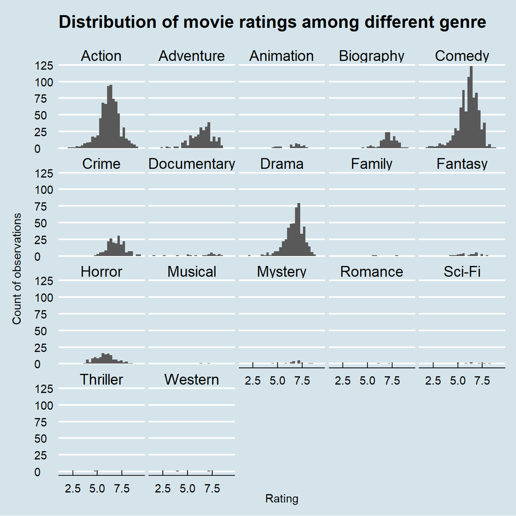

```r
p<-ggplot(movies,aes(rating))+
  geom_histogram()+
  facet_wrap(~genre)+
  theme_economist()+
  labs(title="Distribution of movie ratings among different genre\n", y="Count of observations\n", x="Rating")
p
```

## Use `ggplot` to answer the following

- Examine the relationship between `gross` and `cast_facebook_likes`. Produce a scatterplot and write one sentence discussing whether the number of facebook likes that the cast has received is likely to be a good predictor of how much money a movie will make at the box office. What variable are you going to map to the Y- and X- axes?

```r
glimpse(movies)
```

```
## Rows: 2,961
## Columns: 11
## $ title               <chr> "Avatar", "Titanic", "Jurassic World", "The Ave...
## $ genre               <chr> "Action", "Drama", "Action", "Action", "Action"...
## $ director            <chr> "James Cameron", "James Cameron", "Colin Trevor...
## $ year                <dbl> 2009, 1997, 2015, 2012, 2008, 1999, 1977, 2015,...
## $ duration            <dbl> 178, 194, 124, 173, 152, 136, 125, 141, 164, 93...
## $ gross               <dbl> 7.61e+08, 6.59e+08, 6.52e+08, 6.23e+08, 5.33e+0...
## $ budget              <dbl> 2.37e+08, 2.00e+08, 1.50e+08, 2.20e+08, 1.85e+0...
## $ cast_facebook_likes <dbl> 4834, 45223, 8458, 87697, 57802, 37723, 13485, ...
## $ votes               <dbl> 886204, 793059, 418214, 995415, 1676169, 534658...
## $ reviews             <dbl> 3777, 2843, 1934, 2425, 5312, 3917, 1752, 1752,...
## $ rating              <dbl> 7.9, 7.7, 7.0, 8.1, 9.0, 6.5, 8.7, 7.5, 8.5, 7....
```

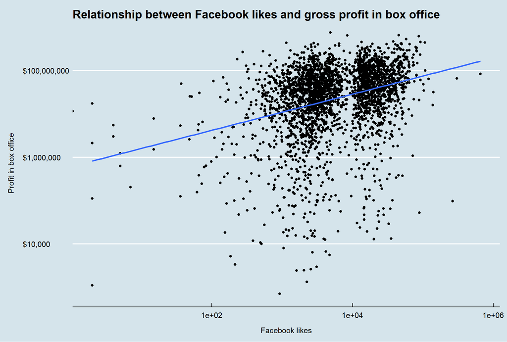

```r
ggplot(movies, aes(y=gross, x=cast_facebook_likes))+
  geom_point() +
  scale_x_log10()+
  scale_y_log10(labels = scales::dollar_format())+
  geom_smooth(method=lm, se=FALSE) +
  theme_economist()+
  labs(title="Relationship between Facebook likes and gross profit in box office", x="\nFacebook likes", y="Profit in box office\n" )
```

The scatterplot and the regression line clearly indicates the relationship between higher cast_facebook_likes and higher gross earnings in the US box office (the regression line shows a positive incline).

- Examine the relationship between `gross` and `budget`. Produce a scatterplot and write one sentence discussing whether budget is likely to be a good predictor of how much money a movie will make at the box office.

Budget is a good indicator of gross revenue a movie can make, and a larger budget will make more money at the box office.

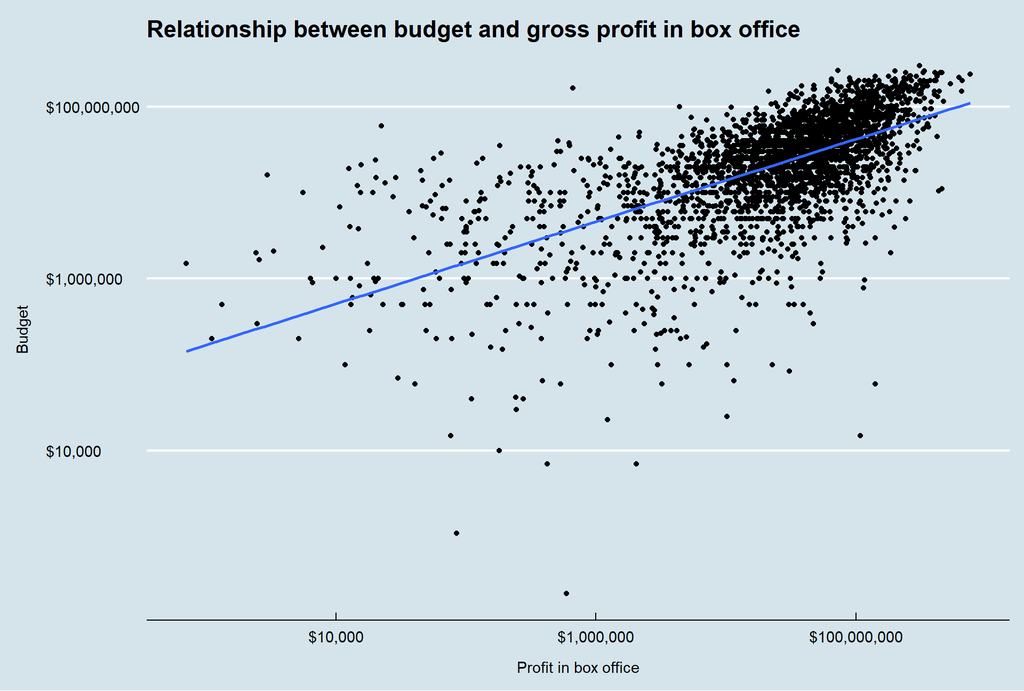

```r
ggplot(movies, aes(x=gross, y=budget))+
  geom_point()+
  scale_x_log10(labels = scales::dollar_format())+
  scale_y_log10(labels = scales::dollar_format())+
  geom_smooth(method=lm, se=FALSE)+
  labs(title="Relationship between budget and gross profit in box office", x="\nProfit in box office", y="Budget\n" )+
  theme_economist()
```

Also, this scatterplot and the regression line clearly indicates the relationship between higher budget and higher gross earnings in the US box office (the regression line shows a positive incline).

- Examine the relationship between `gross` and `rating`. Produce a scatterplot, faceted by `genre` and discuss whether IMDB ratings are likely to be a good predictor of how much money a movie will make at the box office. Is there anything strange in this dataset?

For most genres, the higher the ratings are, the more gross revenue a movie will make at the box office.

In some genres there is even a negative correlation, i.e. Documentary. However, for the genres with many data points, i.e. Action, Adventure, Commedy, Crime, Drama, we can see a slightly positive correlation between the ratings and the money spend in box offices. However, animation, documentary, fantasy and sci-fi are exceptions. For family, romance, musical, thriller and western, the data is not sufficient to tell any relationships. The dataset is biased towards certain genres of movies, and it fail to represent the complete landscape of the movie industry.

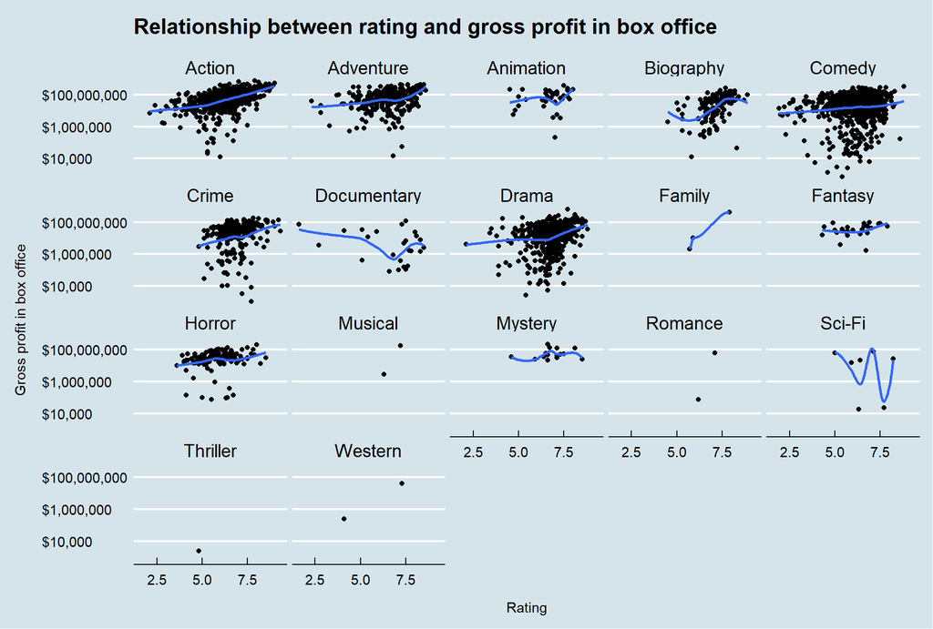

```r
ggplot(movies, aes(y=gross, x=rating))+
  geom_point()+
  scale_y_log10(labels = scales::dollar_format())+
  geom_smooth(mothod=lm, se=FALSE)+
  facet_wrap(~genre)+
  labs(title = "Relationship between rating and gross profit in box office\n", x="\nRating", y="Gross profit in box office\n")+
  theme_economist()
```

# 3 Returns of financial stocks

> You may find useful the material on [finance data sources](https://mfa2021.netlify.app/reference/finance_data/).

We will use the `tidyquant` package to download historical data of stock prices, calculate returns, and examine the distribution of returns.

We must first identify which stocks we want to download data for, and for this we must know their ticker symbol; Apple is known as AAPL, Microsoft as MSFT, McDonald’s as MCD, etc. The file `nyse.csv` contains 508 stocks listed on the NYSE, their ticker `symbol`, `name`, the IPO (Initial Public Offering) year, and the sector and industry the company is in.

```r
nyse <- read_csv("nyse.csv")
glimpse(nyse)
```

```
## Rows: 508
## Columns: 6
## $ symbol        <chr> "MMM", "ABB", "ABT", "ABBV", "ACN", "AAP", "AFL", "A"...
## $ name          <chr> "3M Company", "ABB Ltd", "Abbott Laboratories", "AbbV...
## $ ipo_year      <chr> "n/a", "n/a", "n/a", "2012", "2001", "n/a", "n/a", "1...
## $ sector        <chr> "Health Care", "Consumer Durables", "Health Care", "H...
## $ industry      <chr> "Medical/Dental Instruments", "Electrical Products", ...
## $ summary_quote <chr> "https://www.nasdaq.com/symbol/mmm", "https://www.nas...
```

```r
skim(nyse)
```

Data summary

| Name | nyse |
| --- | --- |
| Number of rows | 508 |
| Number of columns | 6 |
| _______________________ |  |
| Column type frequency: |  |
| character | 6 |
| ________________________ |  |
| Group variables | None |

**Variable type: character**

| skim_variable | n_missing | complete_rate | min | max | empty | n_unique | whitespace |
| --- | --- | --- | --- | --- | --- | --- | --- |
| symbol | 0 | 1 | 1 | 4 | 0 | 508 | 0 |
| name | 0 | 1 | 5 | 48 | 0 | 505 | 0 |
| ipo_year | 0 | 1 | 3 | 4 | 0 | 33 | 0 |
| sector | 0 | 1 | 6 | 21 | 0 | 12 | 0 |
| industry | 0 | 1 | 5 | 62 | 0 | 103 | 0 |
| summary_quote | 0 | 1 | 31 | 34 | 0 | 508 | 0 |

Based on this dataset, create a table and a bar plot that shows the number of companies per sector, in descending order

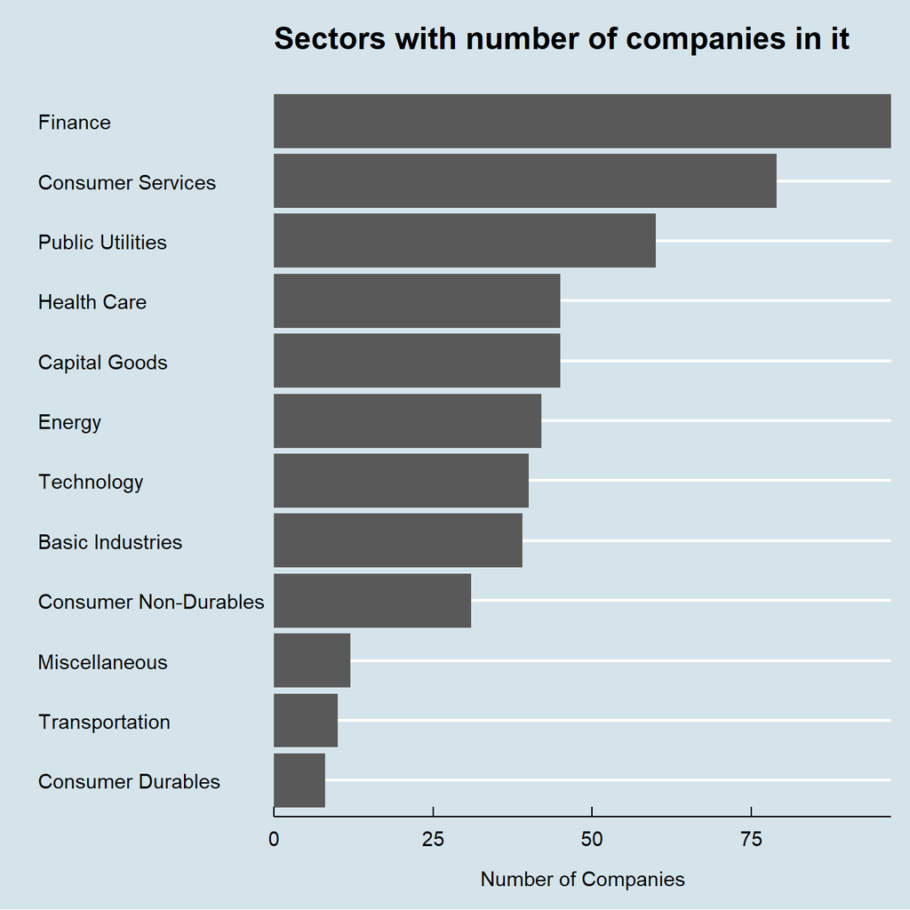

```r
companies_per_sector <- nyse %>%
  group_by(sector)%>%
  summarise(Number_of_Companies = n())%>%
  arrange(desc(Number_of_Companies))

ggplot(companies_per_sector, aes(y=reorder(sector,Number_of_Companies),x=Number_of_Companies))+
  geom_col() +
  theme_economist() +
  labs(title="Sectors with number of companies in it \n", y="", x="\nNumber of Companies") +
  scale_x_continuous(expand = c(0,0))
```

Next, let’s choose the [Dow Jones Industrial Aveareg (DJIA)](https://en.wikipedia.org/wiki/Dow_Jones_Industrial_Average) stocks and their ticker symbols and download some data. Besides the thirty stocks that make up the DJIA, we will also add `SPY` which is an SP500 ETF (Exchange Traded Fund).

```r
djia_url <- "https://en.wikipedia.org/wiki/Dow_Jones_Industrial_Average"

#get tables that exist on URL
tables <- djia_url %>%
  read_html() %>%
  html_nodes(css="table")


# parse HTML tables into a dataframe called djia.
# Use purr::map() to create a list of all tables in URL
djia <- map(tables, . %>%
               html_table(fill=TRUE)%>%
               clean_names())


# constituents
table1 <- djia[[2]] %>% # the second table on the page contains the ticker symbols
  mutate(date_added = ymd(date_added),

         # if a stock is listed on NYSE, its symbol is, e.g., NYSE: MMM
         # We will get prices from yahoo finance which requires just the ticker

         # if symbol contains "NYSE*", the * being a wildcard
         # then we jsut drop the first 6 characters in that string
         ticker = ifelse(str_detect(symbol, "NYSE*"),
                          str_sub(symbol,7,11),
                          symbol)
         )

# we need a vector of strings with just the 30 tickers + SPY
tickers <- table1 %>%
  select(ticker) %>%
  pull() %>% # pull() gets them as a sting of characters
  c("SPY") # and lets us add SPY, the SP500 ETF
```

```r
# Notice the cache=TRUE argument in the chunk options. Because getting data is time consuming, # cache=TRUE means that once it downloads data, the chunk will not run again next time you knit your Rmd

myStocks <- tickers %>%
  tq_get(get  = "stock.prices",
         from = "2000-01-01",
         to   = "2020-08-31") %>%
  group_by(symbol)

glimpse(myStocks) # examine the structure of the resulting data frame
```

```
## Rows: 153,121
## Columns: 8
## Groups: symbol [31]
## $ symbol   <chr> "MMM", "MMM", "MMM", "MMM", "MMM", "MMM", "MMM", "MMM", "M...
## $ date     <date> 2000-01-03, 2000-01-04, 2000-01-05, 2000-01-06, 2000-01-0...
## $ open     <dbl> 48.0, 46.4, 45.6, 47.2, 50.6, 50.2, 50.4, 51.0, 50.7, 50.4...
## $ high     <dbl> 48.2, 47.4, 48.1, 51.2, 51.9, 51.8, 51.2, 51.8, 50.9, 50.5...
## $ low      <dbl> 47.0, 45.3, 45.6, 47.2, 50.0, 50.0, 50.2, 50.4, 50.2, 49.5...
## $ close    <dbl> 47.2, 45.3, 46.6, 50.4, 51.4, 51.1, 50.2, 50.4, 50.4, 49.7...
## $ volume   <dbl> 2173400, 2713800, 3699400, 5975800, 4101200, 3863800, 2357...
## $ adjusted <dbl> 28.1, 26.9, 27.7, 30.0, 30.5, 30.4, 29.9, 30.0, 30.0, 29.5...
```

Financial performance analysis depend on returns; If I buy a stock today for 100 and I sell it tomorrow for 101.75, my one-day return, assuming no transaction costs, is 1.75%. So given the adjusted closing prices, our first step is to calculate daily and monthly returns.

```r
#calculate daily returns
myStocks_returns_daily <- myStocks %>%
  tq_transmute(select     = adjusted,
               mutate_fun = periodReturn,
               period     = "daily",
               type       = "log",
               col_rename = "daily_returns",
               cols = c(nested.col))

#calculate monthly  returns
myStocks_returns_monthly <- myStocks %>%
  tq_transmute(select     = adjusted,
               mutate_fun = periodReturn,
               period     = "monthly",
               type       = "arithmetic",
               col_rename = "monthly_returns",
               cols = c(nested.col))

#calculate yearly returns
myStocks_returns_annual <- myStocks %>%
  group_by(symbol) %>%
  tq_transmute(select     = adjusted,
               mutate_fun = periodReturn,
               period     = "yearly",
               type       = "arithmetic",
               col_rename = "yearly_returns",
               cols = c(nested.col))
```

Create a dataframe and assign it to a new object, where you summarise monthly returns since 2017-01-01 for each of the stocks and `SPY`; min, max, median, mean, SD.

```r
summarise_monthly_returns <- myStocks_returns_monthly %>%
  group_by(symbol)%>%
  summarise(min_month_return = min(monthly_returns),
            max_month_return = max(monthly_returns),
            median_month_return = median(monthly_returns),
            mean_month_return = mean(monthly_returns),
            sd_month_return = sd(monthly_returns)
            )
summarise_monthly_returns
```

```
## # A tibble: 31 x 6
##    symbol min_month_return max_month_return median_month_re~ mean_month_retu~
##    <chr>             <dbl>            <dbl>            <dbl>            <dbl>
##  1 AAPL             -0.577            0.454           0.0352          0.0275
##  2 AMGN             -0.170            0.328           0.0104          0.00916
##  3 AXP              -0.279            0.875           0.0102          0.00818
##  4 BA               -0.458            0.257           0.0179          0.0120
##  5 CAT              -0.353            0.350           0.0133          0.0143
##  6 CRM              -0.360            0.403           0.0205          0.0276
##  7 CSCO             -0.367            0.389           0.0125          0.00495
##  8 CVX              -0.224            0.270           0.0122          0.00852
##  9 DIS              -0.268            0.234           0.0107          0.00980
## 10 DOW              -0.276            0.255           0.0456          0.00898
## # ... with 21 more rows, and 1 more variable: sd_month_return <dbl>
```

Plot a density plot, using `geom_density()`, for each of the stocks

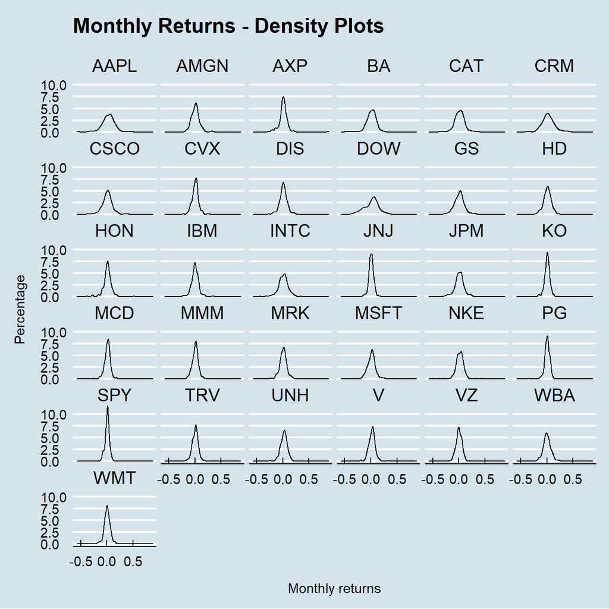

```r
ggplot(myStocks_returns_monthly, aes(x=monthly_returns))+
  geom_density()+
  facet_wrap(~symbol)+
  labs(title='Monthly Returns - Density Plots\n', x="\nMonthly returns", y="Percentage\n")+
  theme_economist()
```

What can you infer from this plot? Which stock is the riskiest? The least risky?

Finally, produce a plot that shows the expected monthly return (mean) of a stock on the Y axis and the risk (standard deviation) in the X-axis. Please use `ggrepel::geom_text_repel()` to label each stock with its ticker symbol

[figure not shown]

```r
library(ggrepel)

ggplot(summarise_monthly_returns, aes(y=mean_month_return, x=sd_month_return, label=symbol))+
  geom_point() +
  geom_text_repel()+
  geom_lm(method=lm,se=FALSE)+
  theme_economist()+
  labs(title="Relation between monthly return and risk\n", y="Monthly return", x="\nRisk (standard deviation)")
```

What can you infer from this plot? Are there any stocks which, while being riskier, do not have a higher expected return?

From the plot we can infer that as the mean monthly return rises, so does the standard deviation, which makes sense, since a higher return usually indicates higher variability in prices, meaning that the higher the return of the stock the more risk associated with the returns. There are some cases, where the volatility (standard deviation) is high, with a lower mean monthly return. In particular, the biggest outliar is DOW, with a mean monthly return smaller than 0.01 and the highest standard deviation. There are some other cases bordering on having outliar-like characteristics, like Cisco Systems, american express and other financial services stocks like JP Morgan and Goldman Sachs.

# 4 On your own: IBM HR Analytics

For this task, you will analyse a data set on Human Resoruce Analytics. The [IBM HR Analytics Employee Attrition & Performance data set](https://www.kaggle.com/pavansubhasht/ibm-hr-analytics-attrition-dataset) is a fictional data set created by IBM data scientists. Among other things, the data set includes employees’ income, their distance from work, their position in the company, their level of education, etc. A full description can be found on the website.

First let us load the data

```r
hr_dataset <- read_csv(here::here("datasets_1067_1925_WA_Fn-UseC_-HR-Employee-Attrition.csv"))
glimpse(hr_dataset)
```

```
## Rows: 1,470
## Columns: 35
## $ Age                      <dbl> 41, 49, 37, 33, 27, 32, 59, 30, 38, 36, 35...
## $ Attrition                <chr> "Yes", "No", "Yes", "No", "No", "No", "No"...
## $ BusinessTravel           <chr> "Travel_Rarely", "Travel_Frequently", "Tra...
## $ DailyRate                <dbl> 1102, 279, 1373, 1392, 591, 1005, 1324, 13...
## $ Department               <chr> "Sales", "Research & Development", "Resear...
## $ DistanceFromHome         <dbl> 1, 8, 2, 3, 2, 2, 3, 24, 23, 27, 16, 15, 2...
## $ Education                <dbl> 2, 1, 2, 4, 1, 2, 3, 1, 3, 3, 3, 2, 1, 2, ...
## $ EducationField           <chr> "Life Sciences", "Life Sciences", "Other",...
## $ EmployeeCount            <dbl> 1, 1, 1, 1, 1, 1, 1, 1, 1, 1, 1, 1, 1, 1, ...
## $ EmployeeNumber           <dbl> 1, 2, 4, 5, 7, 8, 10, 11, 12, 13, 14, 15, ...
## $ EnvironmentSatisfaction  <dbl> 2, 3, 4, 4, 1, 4, 3, 4, 4, 3, 1, 4, 1, 2, ...
## $ Gender                   <chr> "Female", "Male", "Male", "Female", "Male"...
## $ HourlyRate               <dbl> 94, 61, 92, 56, 40, 79, 81, 67, 44, 94, 84...
```

[output cut: 22 more lines]

I am going to clean the data set, as variable names are in capital letters, some variables are not really necessary, and some variables, e.g., `education` are given as a number rather than a more useful description

```r
hr_cleaned <- hr_dataset %>%
  clean_names() %>%
  mutate(
    education = case_when(
      education == 1 ~ "Below College",
      education == 2 ~ "College",
      education == 3 ~ "Bachelor",
      education == 4 ~ "Master",
      education == 5 ~ "Doctor"
    ),
    environment_satisfaction = case_when(
      environment_satisfaction == 1 ~ "Low",
      environment_satisfaction == 2 ~ "Medium",
      environment_satisfaction == 3 ~ "High",
      environment_satisfaction == 4 ~ "Very High"
    ),
    job_satisfaction = case_when(
      job_satisfaction == 1 ~ "Low",
      job_satisfaction == 2 ~ "Medium",
      job_satisfaction == 3 ~ "High",
      job_satisfaction == 4 ~ "Very High"
    ),
    performance_rating = case_when(
      performance_rating == 1 ~ "Low",
      performance_rating == 2 ~ "Good",
      performance_rating == 3 ~ "Excellent",
      performance_rating == 4 ~ "Outstanding"
    ),
    work_life_balance = case_when(
      work_life_balance == 1 ~ "Bad",
      work_life_balance == 2 ~ "Good",
      work_life_balance == 3 ~ "Better",
      work_life_balance == 4 ~ "Best"
    )
  ) %>%
  select(age, attrition, daily_rate, department,
         distance_from_home, education,
         gender, job_role,environment_satisfaction,
         job_satisfaction, marital_status,
         monthly_income, num_companies_worked, percent_salary_hike,
         performance_rating, total_working_years,
         work_life_balance, years_at_company,
         years_since_last_promotion)
```

Produce a one-page summary describing this dataset. Here is a non-exhaustive list of questions:

1. How often do people leave the company (`attrition`)
2. How are `age`, `years_at_company`, `monthly_income` and `years_since_last_promotion` distributed? can you roughly guess which of these variables is closer to Normal just by looking at summary statistics?
3. How are `job_satisfaction` and `work_life_balance` distributed? Don’t just report counts, but express categories as % of total
4. Is there any relationship between monthly income and education? Monthly income and gender?
5. Plot a boxplot of income vs job role. Make sure the highest-paid job roles appear first
6. Calculate and plot a bar chart of the mean (or median?) income by education level.
7. Plot the distribution of income by education level. Use a facet_wrap and a theme from `ggthemes`
8. Plot income vs age, faceted by `job_role`

first, let’s look at the cleaned data

```r
glimpse(hr_cleaned)
```

```
## Rows: 1,470
## Columns: 19
## $ age                        <dbl> 41, 49, 37, 33, 27, 32, 59, 30, 38, 36, ...
## $ attrition                  <chr> "Yes", "No", "Yes", "No", "No", "No", "N...
## $ daily_rate                 <dbl> 1102, 279, 1373, 1392, 591, 1005, 1324, ...
## $ department                 <chr> "Sales", "Research & Development", "Rese...
## $ distance_from_home         <dbl> 1, 8, 2, 3, 2, 2, 3, 24, 23, 27, 16, 15,...
## $ education                  <chr> "College", "Below College", "College", "...
## $ gender                     <chr> "Female", "Male", "Male", "Female", "Mal...
## $ job_role                   <chr> "Sales Executive", "Research Scientist",...
## $ environment_satisfaction   <chr> "Medium", "High", "Very High", "Very Hig...
## $ job_satisfaction           <chr> "Very High", "Medium", "High", "High", "...
## $ marital_status             <chr> "Single", "Married", "Single", "Married"...
## $ monthly_income             <dbl> 5993, 5130, 2090, 2909, 3468, 3068, 2670...
## $ num_companies_worked       <dbl> 8, 1, 6, 1, 9, 0, 4, 1, 0, 6, 0, 0, 1, 0...
## $ percent_salary_hike        <dbl> 11, 23, 15, 11, 12, 13, 20, 22, 21, 13, ...
## $ performance_rating         <chr> "Excellent", "Outstanding", "Excellent",...
## $ total_working_years        <dbl> 8, 10, 7, 8, 6, 8, 12, 1, 10, 17, 6, 10,...
## $ work_life_balance          <chr> "Bad", "Better", "Better", "Better", "Be...
## $ years_at_company           <dbl> 6, 10, 0, 8, 2, 7, 1, 1, 9, 7, 5, 9, 5, ...
## $ years_since_last_promotion <dbl> 0, 1, 0, 3, 2, 3, 0, 0, 1, 7, 0, 0, 4, 1...
```

```r
skim(hr_cleaned)
```

Data summary

| Name | hr_cleaned |
| --- | --- |
| Number of rows | 1470 |
| Number of columns | 19 |
| _______________________ |  |
| Column type frequency: |  |
| character | 10 |
| numeric | 9 |
| ________________________ |  |
| Group variables | None |

**Variable type: character**

| skim_variable | n_missing | complete_rate | min | max | empty | n_unique | whitespace |
| --- | --- | --- | --- | --- | --- | --- | --- |
| attrition | 0 | 1 | 2 | 3 | 0 | 2 | 0 |
| department | 0 | 1 | 5 | 22 | 0 | 3 | 0 |
| education | 0 | 1 | 6 | 13 | 0 | 5 | 0 |
| gender | 0 | 1 | 4 | 6 | 0 | 2 | 0 |
| job_role | 0 | 1 | 7 | 25 | 0 | 9 | 0 |
| environment_satisfaction | 0 | 1 | 3 | 9 | 0 | 4 | 0 |
| job_satisfaction | 0 | 1 | 3 | 9 | 0 | 4 | 0 |
| marital_status | 0 | 1 | 6 | 8 | 0 | 3 | 0 |
| performance_rating | 0 | 1 | 9 | 11 | 0 | 2 | 0 |
| work_life_balance | 0 | 1 | 3 | 6 | 0 | 4 | 0 |

**Variable type: numeric**

| skim_variable | n_missing | complete_rate | mean | sd | p0 | p25 | p50 | p75 | p100 | hist |
| --- | --- | --- | --- | --- | --- | --- | --- | --- | --- | --- |
| age | 0 | 1 | 36.92 | 9.14 | 18 | 30 | 36 | 43 | 60 | ▂▇▇▃▂ |
| daily_rate | 0 | 1 | 802.49 | 403.51 | 102 | 465 | 802 | 1157 | 1499 | ▇▇▇▇▇ |
| distance_from_home | 0 | 1 | 9.19 | 8.11 | 1 | 2 | 7 | 14 | 29 | ▇▅▂▂▂ |
| monthly_income | 0 | 1 | 6502.93 | 4707.96 | 1009 | 2911 | 4919 | 8379 | 19999 | ▇▅▂▁▂ |
| num_companies_worked | 0 | 1 | 2.69 | 2.50 | 0 | 1 | 2 | 4 | 9 | ▇▃▂▂▁ |
| percent_salary_hike | 0 | 1 | 15.21 | 3.66 | 11 | 12 | 14 | 18 | 25 | ▇▅▃▂▁ |
| total_working_years | 0 | 1 | 11.28 | 7.78 | 0 | 6 | 10 | 15 | 40 | ▇▇▂▁▁ |
| years_at_company | 0 | 1 | 7.01 | 6.13 | 0 | 3 | 5 | 9 | 40 | ▇▂▁▁▁ |
| years_since_last_promotion | 0 | 1 | 2.19 | 3.22 | 0 | 0 | 1 | 3 | 15 | ▇▁▁▁▁ |

## 4.1 count on attrition

```r
hr_cleaned %>%
  group_by(attrition) %>%
  count() %>%
  mutate(frequency = n/length(hr_cleaned$attrition))
```

```
## # A tibble: 2 x 3
## # Groups:   attrition [2]
##   attrition     n frequency
##   <chr>     <int>     <dbl>
## 1 No         1233     0.839
## 2 Yes         237     0.161
```

## 4.2 distribution of `age`, `years_at_company`, `monthly_income` and `years_since_last_promotion`

- age, years_at_company, monthly_income and years_since_last_promotion are right skewed
- age is closer to normal distribution

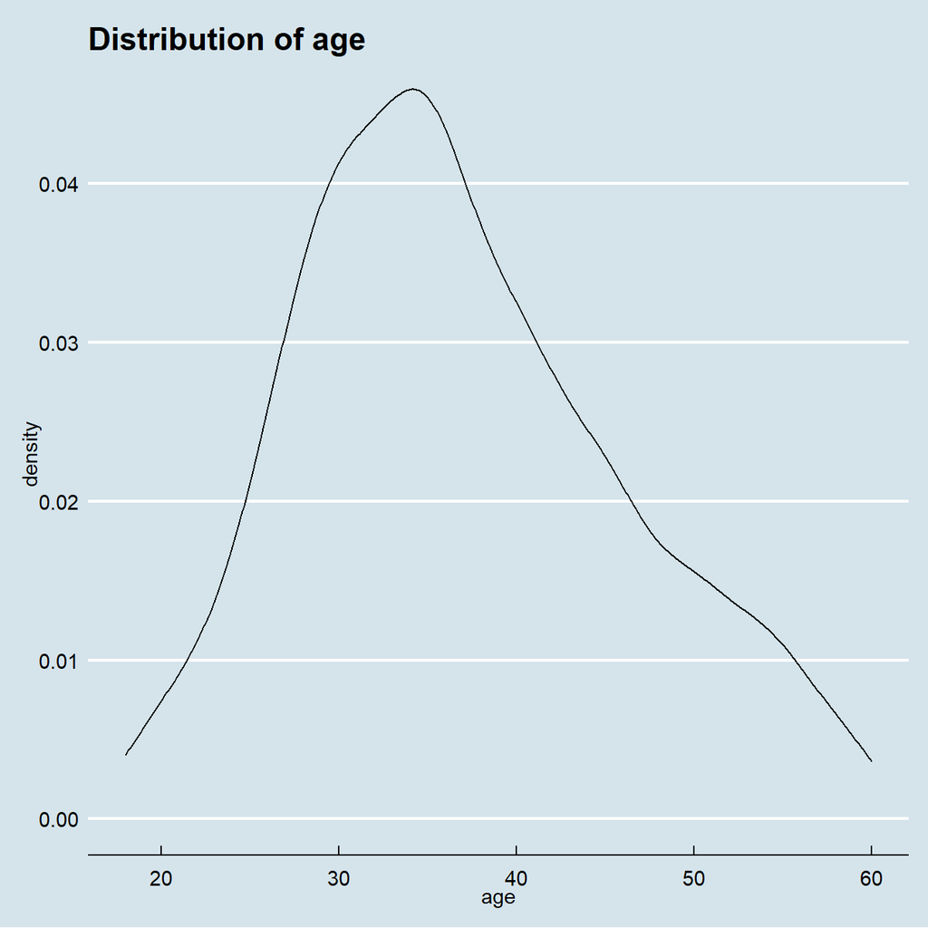

```r
hr_cleaned %>%
  ggplot(aes(age)) +
  geom_density() +
  labs(title = "Distribution of age") +
  theme_economist()
```

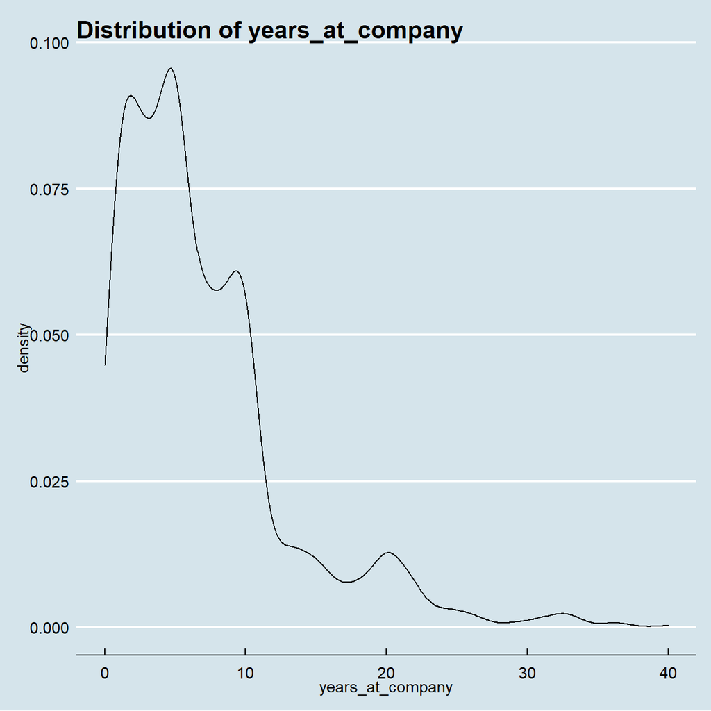

```r
hr_cleaned %>%
  ggplot(aes(years_at_company)) +
  geom_density() +
  labs(title = "Distribution of years_at_company") +
  theme_economist()
```

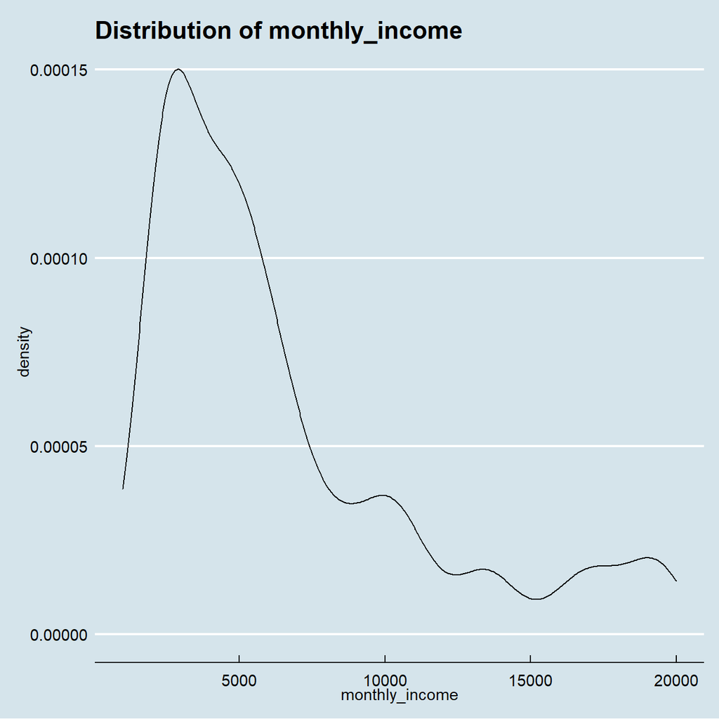

```r
hr_cleaned %>%
  ggplot(aes(monthly_income)) +
  geom_density() +
  labs(title = "Distribution of monthly_income") +
  theme_economist()
```

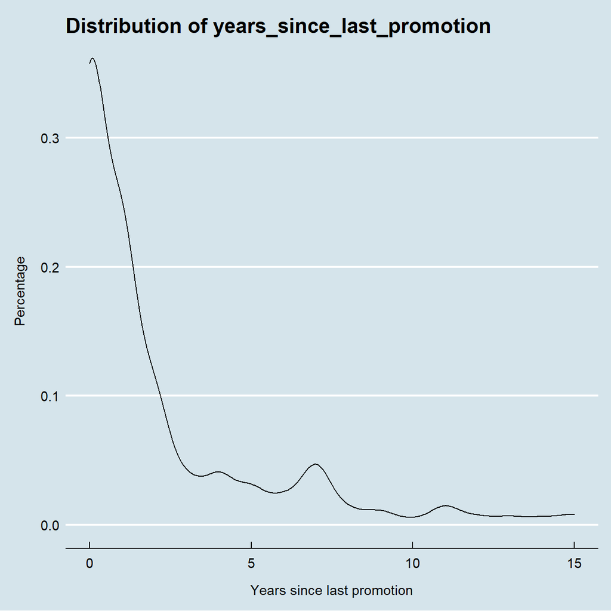

```r
hr_cleaned %>%
  ggplot(aes(years_since_last_promotion)) +
  geom_density() +
  labs(title = "Distribution of years_since_last_promotion", y="Percentage\n", x="\nYears since last promotion") +
  theme_economist()
```

## 4.3 distribution of `job_satisfaction` and `work_life_balance` distributed? Don’t just report counts, but express categories as % of total

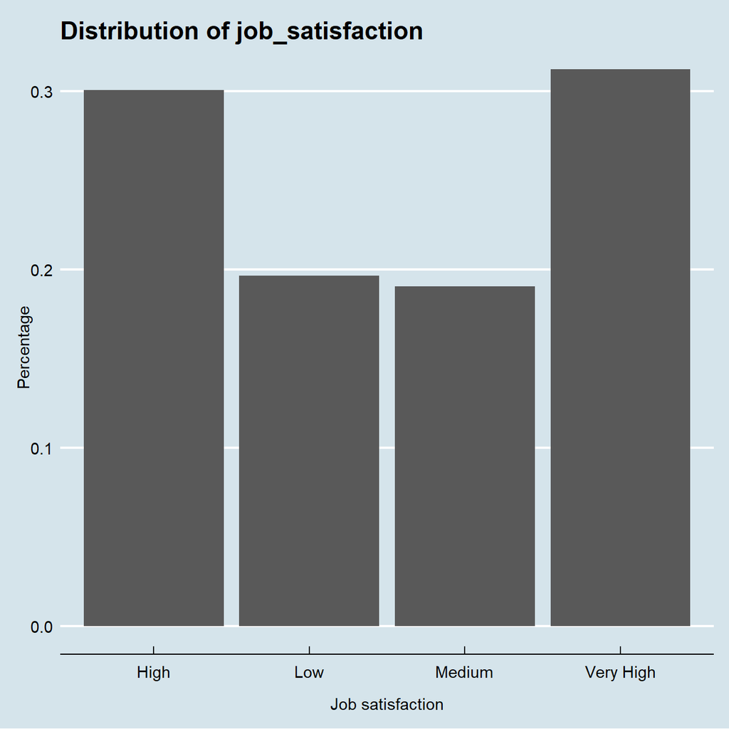

```r
hr_cleaned %>%
  group_by(job_satisfaction) %>%
  count() %>%
  mutate(percent_job_satisfaction = n/length(hr_cleaned$job_satisfaction)) %>%
  ggplot(aes(x = job_satisfaction, y = percent_job_satisfaction)) +
  geom_col() +
  labs(title = "Distribution of job_satisfaction",x="\nJob satisfaction",y="Percentage") +
  theme_economist()
```

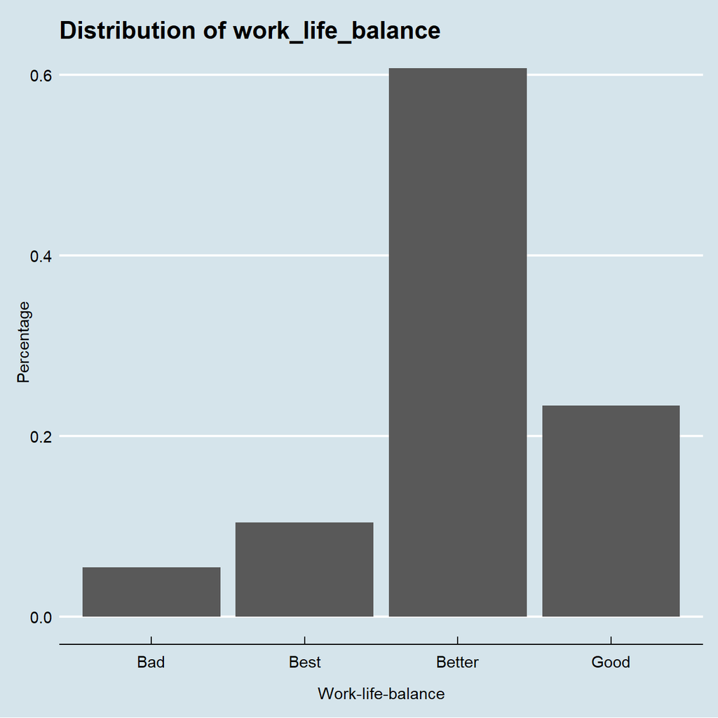

```r
hr_cleaned %>%
  group_by(work_life_balance) %>%
  count() %>%
  mutate(percent_work_life_balance = n/length(hr_cleaned$work_life_balance)) %>%
  ggplot(aes(x = work_life_balance, y = percent_work_life_balance)) +
  geom_col() +
  labs(title = "Distribution of work_life_balance", x="\nWork-life-balance",y="Percentage") +
  theme_economist()
```

## 4.4 relationship between income and education/gender

```r
  hr_cleaned %>%
  group_by(education) %>%
  summarise(n = count(education), mean_income = AVERAGE(monthly_income), median_income = median(monthly_income))
```

[output not shown]

```r
hr_cleaned %>%
  group_by(gender) %>%
  summarise(n = count(gender), mean_income = AVERAGE(monthly_income), median_income = median(monthly_income))
```

[output not shown]

## 4.5 relationship between income and job role

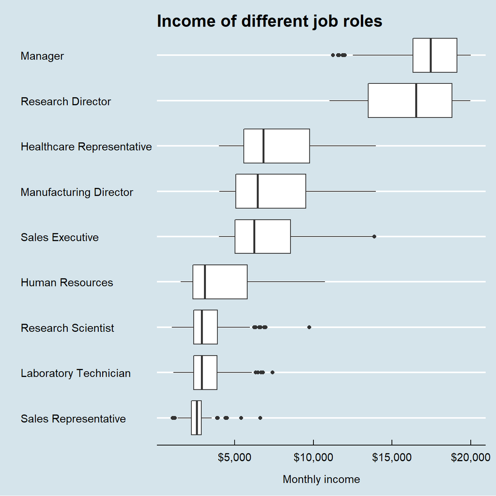

```r
hr_cleaned %>%
  ggplot(aes(y = reorder(job_role, monthly_income), x=monthly_income)) +
  geom_boxplot() +
  labs(title = "Income of different job roles", y = "", x="\nMonthly income") +
  theme_economist()+
  scale_x_continuous(labels = scales::dollar_format())
```

## 4.6 relationship between mean/median income by education level.

[figure not shown]

```r
hr_cleaned %>%
  group_by(education) %>%
  summarise(mean_income = AVERAGE(monthly_income)) %>%
  ggplot(aes(x = reorder(education, -mean_income), y = mean_income)) +
  geom_col() +
  labs(title = "Mean income by education", y="Mean income\n", x="\nEducation level") +
  theme_economist()
```

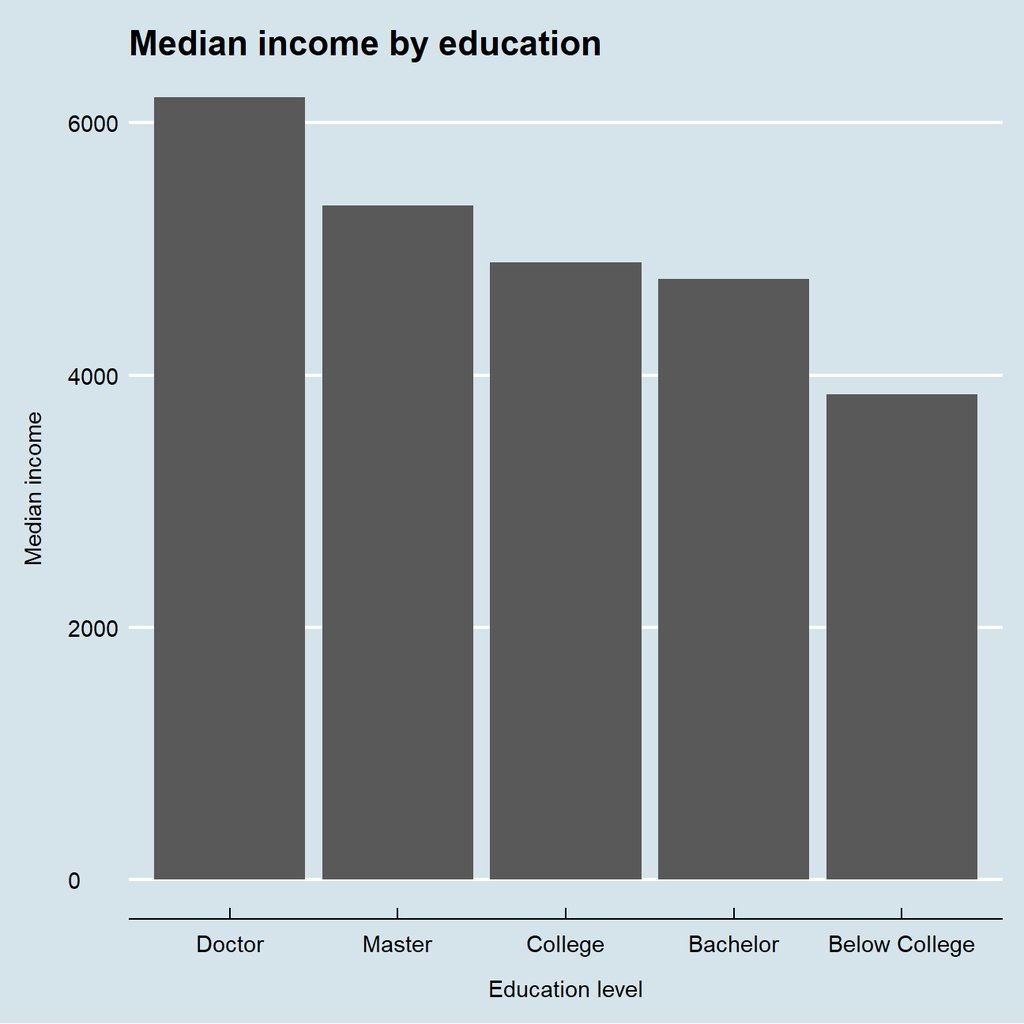

```r
hr_cleaned %>%
  group_by(education) %>%
  summarise(median_income = median(monthly_income)) %>%
  ggplot(aes(x = reorder(education, -median_income), y = median_income)) +
  geom_col() +
  labs(title = "Median income by education", y="Median income\n", x="\nEducation level") +
  theme_economist()
```

## 4.7 distribution of income by education level

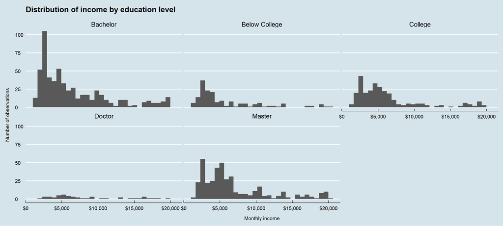

```r
hr_cleaned %>%
  ggplot(aes(monthly_income)) +
  geom_histogram() +
  facet_wrap(~education) +
  theme_economist() +
  labs(title = "Distribution of income by education level\n", y = "Number of observations\n", x="\nMonthly income")+
  scale_x_continuous(labels= scales::dollar_format())
```

## 4.8 income vs age, faceted by `job_role`

[figure not shown]

```r
hr_cleaned %>%
  ggplot(aes(x = age, y = monthly_income)) +
  geom_point() +
  facet_wrap(~job_role) +
  labs(title = "Income vs age, by job role\n", x="\nAge", y="Monthly income\n") +
  geom_lm(method=lm,se=FALSE)+
  theme_economist()
```

## 4.9 relationship between marital_status and median income

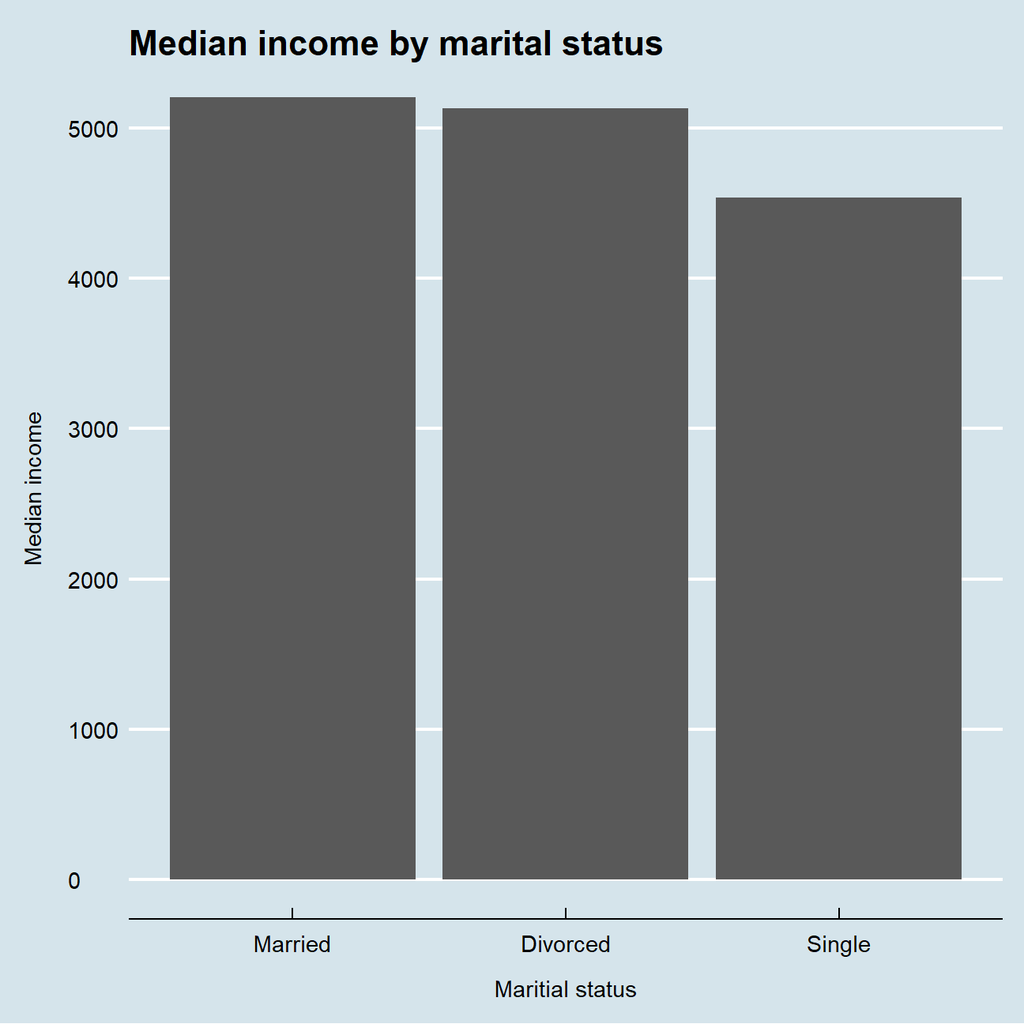

```r
hr_cleaned %>%
  group_by(marital_status) %>%
  summarise(median_income = median(monthly_income)) %>%
  ggplot(aes(x = reorder(marital_status, -median_income), y = median_income)) +
  geom_col() +
  labs(title = "Median income by marital status", x="\nMaritial status", y="Median income\n") +
  theme_economist()
```

# 5 Challenge 1: Chart on homicide and suicide

```r
# Replicate Figure 3
library(ggrepel)
CDC_Males <- read_csv("CDC_Males.csv")
glimpse(CDC_Males)
```

```
## Rows: 104
## Columns: 28
## $ ST                      <chr> "AK", "AK", "AL", "AL", "AR", "AR", "AZ", "...
## $ State                   <chr> "Alaska", "Alaska", "Alabama", "Alabama", "...
## $ Population.Black        <dbl> 153664, 153664, 5376635, 5376635, 1991165, ...
## $ Population.White        <dbl> 2274605, 2274605, 14267619, 14267619, 97470...
## $ Deaths.homicide.Black   <dbl> 23, NA, 183, 1812, 667, 90, 300, 40, 3712, ...
## $ Deaths.homicide.White   <dbl> 78, 10, 124, 620, 416, 110, 586, 145, 1399,...
## $ crude.homicide.Black    <dbl> 14.97, NA, 3.40, 33.70, 33.50, 4.52, 22.06,...
## $ crude.homicide.White    <dbl> 3.43, NA, 0.87, 4.35, 4.27, 1.13, 3.46, 0.8...
## $ adjusted.homicide.Black <dbl> 12.30, NA, 3.51, 33.00, 33.39, 4.81, 20.40,...
## $ adjusted.homicide.White <dbl> 3.24, NA, 0.85, 4.47, 4.39, 1.13, 3.63, 0.9...
## $ Deaths.suicide.Black    <dbl> 23, 12, 148, 370, 118, 75, 101, 80, 492, 63...
## $ Deaths.suicide.White    <dbl> 535, 196, 1222, 3195, 2154, 1027, 4146, 197...
## $ crude.suicide.Black     <dbl> 14.97, NA, 2.75, 6.88, 5.93, 3.77, 7.43, 5....
## $ crude.suicide.White     <dbl> 23.52, 8.62, 8.56, 22.39, 22.10, 10.54, 24....
## $ adjusted.suicide.Black  <dbl> 12.77, NA, 2.84, 7.20, 6.25, 3.93, 7.51, 5....
## $ adjusted.suicide.White  <dbl> 23.47, 8.21, 8.64, 20.97, 20.98, 10.89, 21....
## $ type                    <chr> "Firearm", "Non-Firearm", "Non-Firearm", "F...
## $ crude.RD.suicide        <dbl> -8.55, NA, -5.81, -15.51, -16.17, -6.77, -1...
## $ adj.RD.suicide          <dbl> -10.70, NA, -5.80, -13.77, -14.73, -6.96, -...
## $ crude.RD.homicide       <dbl> 11.54, NA, 2.53, 29.35, 29.23, 3.39, 18.60,...
## $ adj.RD.homicide         <dbl> 9.06, NA, 2.66, 28.53, 29.00, 3.68, 16.77, ...
## $ ST.order.RD.homicide    <chr> "AK", "AK", "AL", "AL", "AR", "AR", "AZ", "...
## $ ST.order.RD.suicide     <chr> "AK", "AK", "AL", "AL", "AR", "AR", "AZ", "...
## $ gun.house.prev          <dbl> 59.8, 59.8, 52.2, 52.2, 58.8, 58.8, 32.3, 3...
## $ gun.house.prev.category <chr> "45.0%-65.5%", "45.0%-65.5%", "45.0%-65.5%"...
## $ average.pop.white       <dbl> 252734, 252734, 1585291, 1585291, 1083003, ...
## $ average.pop.black       <dbl> 17074, 17074, 597404, 597404, 221241, 22124...
## $ type.fac                <chr> "Firearm-related", "Firearm-unrelated", "Fi...
```

```r
skim(CDC_Males)
```

Data summary

| Name | CDC_Males |
| --- | --- |
| Number of rows | 104 |
| Number of columns | 28 |
| _______________________ |  |
| Column type frequency: |  |
| character | 7 |
| numeric | 21 |
| ________________________ |  |
| Group variables | None |

**Variable type: character**

| skim_variable | n_missing | complete_rate | min | max | empty | n_unique | whitespace |
| --- | --- | --- | --- | --- | --- | --- | --- |
| ST | 0 | 1.00 | 2 | 2 | 0 | 52 | 0 |
| State | 0 | 1.00 | 4 | 20 | 0 | 52 | 0 |
| type | 0 | 1.00 | 7 | 11 | 0 | 2 | 0 |
| ST.order.RD.homicide | 0 | 1.00 | 2 | 2 | 0 | 52 | 0 |
| ST.order.RD.suicide | 0 | 1.00 | 2 | 2 | 0 | 52 | 0 |
| gun.house.prev.category | 4 | 0.96 | 11 | 11 | 0 | 4 | 0 |
| type.fac | 0 | 1.00 | 15 | 17 | 0 | 2 | 0 |

**Variable type: numeric**

| skim_variable | n_missing | complete_rate | mean | sd | p0 | p25 | p50 | p75 | p100 | hist |
| --- | --- | --- | --- | --- | --- | --- | --- | --- | --- | --- |
| Population.Black | 2 | 0.98 | 3.41e+06 | 3.95e+06 | 4.05e+04 | 3.07e+05 | 1.47e+06 | 5.98e+06 | 1.35e+07 | ▇▂▂▁▁ |
| Population.White | 2 | 0.98 | 1.74e+07 | 1.53e+07 | 1.01e+06 | 5.69e+06 | 1.35e+07 | 2.28e+07 | 6.93e+07 | ▇▃▁▁▁ |
| Deaths.homicide.Black | 21 | 0.80 | 1.43e+03 | 5.94e+03 | 1.10e+01 | 7.75e+01 | 2.47e+02 | 1.34e+03 | 5.38e+04 | ▇▁▁▁▁ |
| Deaths.homicide.White | 2 | 0.98 | 4.83e+02 | 1.91e+03 | 1.00e+01 | 5.42e+01 | 1.40e+02 | 3.83e+02 | 1.84e+04 | ▇▁▁▁▁ |
| crude.homicide.Black | 26 | 0.75 | 1.78e+01 | 1.61e+01 | 1.70e+00 | 3.47e+00 | 1.48e+01 | 2.93e+01 | 6.27e+01 | ▇▃▃▁▁ |
| crude.homicide.White | 10 | 0.90 | 1.47e+00 | 1.13e+00 | 2.70e-01 | 7.00e-01 | 1.01e+00 | 1.90e+00 | 4.74e+00 | ▇▂▁▁▁ |
| adjusted.homicide.Black | 26 | 0.75 | 1.68e+01 | 1.52e+01 | 1.68e+00 | 3.48e+00 | 1.29e+01 | 2.78e+01 | 5.94e+01 | ▇▃▃▁▁ |
| adjusted.homicide.White | 10 | 0.90 | 1.50e+00 | 1.17e+00 | 2.40e-01 | 6.70e-01 | 9.90e-01 | 1.98e+00 | 4.79e+00 | ▇▂▁▁▁ |
| Deaths.suicide.Black | 19 | 0.82 | 3.88e+02 | 1.25e+03 | 1.10e+01 | 5.70e+01 | 1.20e+02 | 3.23e+02 | 8.93e+03 | ▇▁▁▁▁ |
| Deaths.suicide.White | 0 | 1.00 | 4.53e+03 | 1.63e+04 | 2.30e+01 | 7.20e+02 | 1.73e+03 | 3.37e+03 | 1.39e+05 | ▇▁▁▁▁ |
| crude.suicide.Black | 26 | 0.75 | 5.35e+00 | 2.00e+00 | 1.62e+00 | 4.24e+00 | 5.24e+00 | 6.33e+00 | 1.50e+01 | ▃▇▁▁▁ |
| crude.suicide.White | 0 | 1.00 | 1.38e+01 | 5.52e+00 | 2.27e+00 | 1.01e+01 | 1.22e+01 | 1.71e+01 | 2.96e+01 | ▁▇▃▃▁ |
| adjusted.suicide.Black | 26 | 0.75 | 5.43e+00 | 1.87e+00 | 1.79e+00 | 4.33e+00 | 5.41e+00 | 6.41e+00 | 1.28e+01 | ▃▇▅▁▁ |
| adjusted.suicide.White | 0 | 1.00 | 1.32e+01 | 5.06e+00 | 2.35e+00 | 9.72e+00 | 1.18e+01 | 1.62e+01 | 2.86e+01 | ▁▇▃▂▁ |
| crude.RD.suicide | 26 | 0.75 | -8.37e+00 | 4.30e+00 | -1.93e+01 | -1.09e+01 | -6.85e+00 | -5.45e+00 | 1.78e+00 | ▂▃▅▇▁ |
| adj.RD.suicide | 26 | 0.75 | -7.55e+00 | 3.63e+00 | -1.56e+01 | -9.84e+00 | -6.50e+00 | -5.26e+00 | 1.83e+00 | ▃▃▇▃▁ |
| crude.RD.homicide | 28 | 0.73 | 1.59e+01 | 1.51e+01 | 1.11e+00 | 2.72e+00 | 1.25e+01 | 2.63e+01 | 6.00e+01 | ▇▃▃▁▁ |
| adj.RD.homicide | 28 | 0.73 | 1.49e+01 | 1.42e+01 | 1.27e+00 | 2.77e+00 | 1.11e+01 | 2.38e+01 | 5.66e+01 | ▇▃▂▁▁ |
| gun.house.prev | 4 | 0.96 | 3.90e+01 | 1.41e+01 | 1.02e+01 | 3.23e+01 | 4.03e+01 | 4.65e+01 | 6.55e+01 | ▃▂▇▅▃ |
| average.pop.white | 2 | 0.98 | 1.94e+06 | 1.70e+06 | 1.13e+05 | 6.33e+05 | 1.50e+06 | 2.53e+06 | 7.70e+06 | ▇▃▁▁▁ |
| average.pop.black | 2 | 0.98 | 3.78e+05 | 4.38e+05 | 4.50e+03 | 3.41e+04 | 1.64e+05 | 6.65e+05 | 1.51e+06 | ▇▂▂▁▁ |

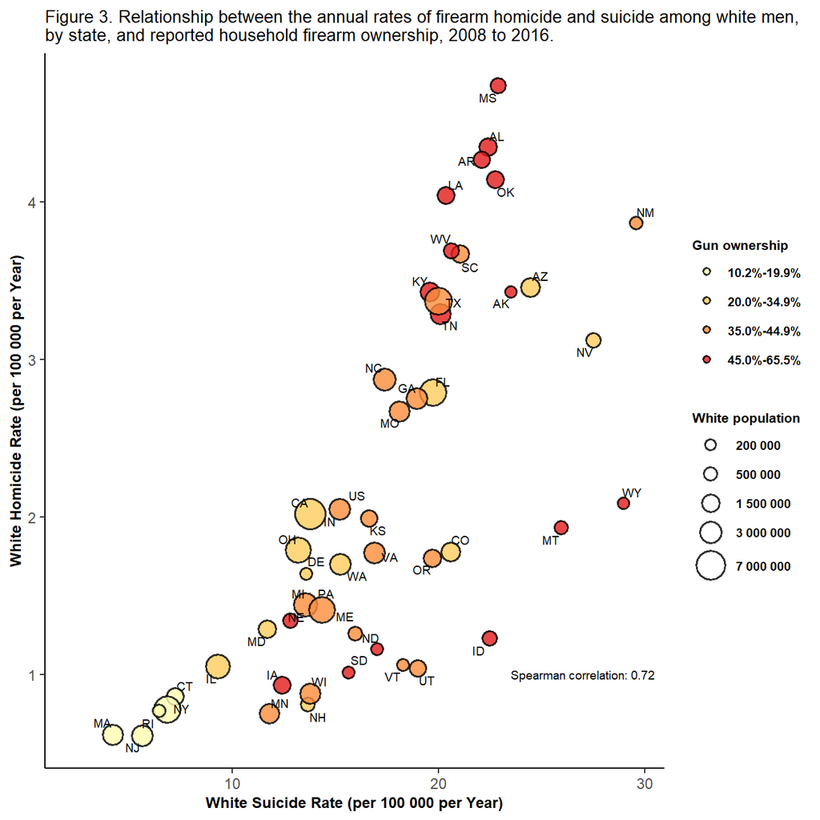

```r
CDC_Males_Firearm<-
CDC_Males%>%
  filter(type.fac=="Firearm-related") #filter for firearm-related only

  ggplot(CDC_Males_Firearm, aes(x=crude.suicide.White, y=crude.homicide.White,size= average.pop.white, label=ST)) + #x-axis: white suicide rate, y-axis: white homicide rate, size of points by average white population, label points by state
  geom_point(aes(fill=gun.house.prev.category), color="black", stroke=0.8, shape=21, alpha=.8)+ #fill points by gun ownership category, outline color black, transparency .8, shape 21 because it is circle with fill and outline, stroke .8 is thickness of outline
  scale_fill_brewer(type="seq",palette="YlOrRd", direction=1,breaks= c("10.2%-19.9%", "20.0%-34.9%","35.0%-44.9%","45.0%-65.5%"),labels=c("10.2%-19.9%", "20.0%-34.9%","35.0%-44.9%","45.0%-65.5%")) + #colorscheme from colorbrewer2
  ggtitle("Figure 3. Relationship between the annual rates of firearm homicide and suicide among white men, \nby state, and reported household firearm ownership, 2008 to 2016.") + #plot title
  xlab("White Suicide Rate (per 100 000 per Year)") + ylab("White Homicide Rate (per 100 000 per Year)")+ #x and y axis labels
 theme_classic()+ # white background
  theme(plot.title= element_text(color="black", size=10), axis.title.x= element_text(color="black", size=9, face="bold"), axis.title.y=element_text(color="black", size=9, face="bold"),legend.title=element_text(face="bold", size=8), legend.text=element_text(face="bold", size=7))+ #font size and type for title, legend, and axis labels
  labs(fill="Gun ownership",size="White population") + #legend titles
  guides(fill=guide_legend(order=1), size=guide_legend(order=2)) + # reorder legend
  scale_size_continuous(breaks=c(200000,500000,1500000,3000000,7000000), labels= c("200 000", "500 000","1 500 000", "3 000 000", "7 000 000"), range=c(2,8))+ #legend scale and labels
  geom_text_repel(segment.alpha=0, size=2.5)+ # point labels font and positioning
    annotate(geom="text", x=27, y=1, label="Spearman correlation: 0.72", size=2.5)+ #add Spearman correlation annotation

         NULL
```

# 6 Challenge 2: 2016 California Contributors plots

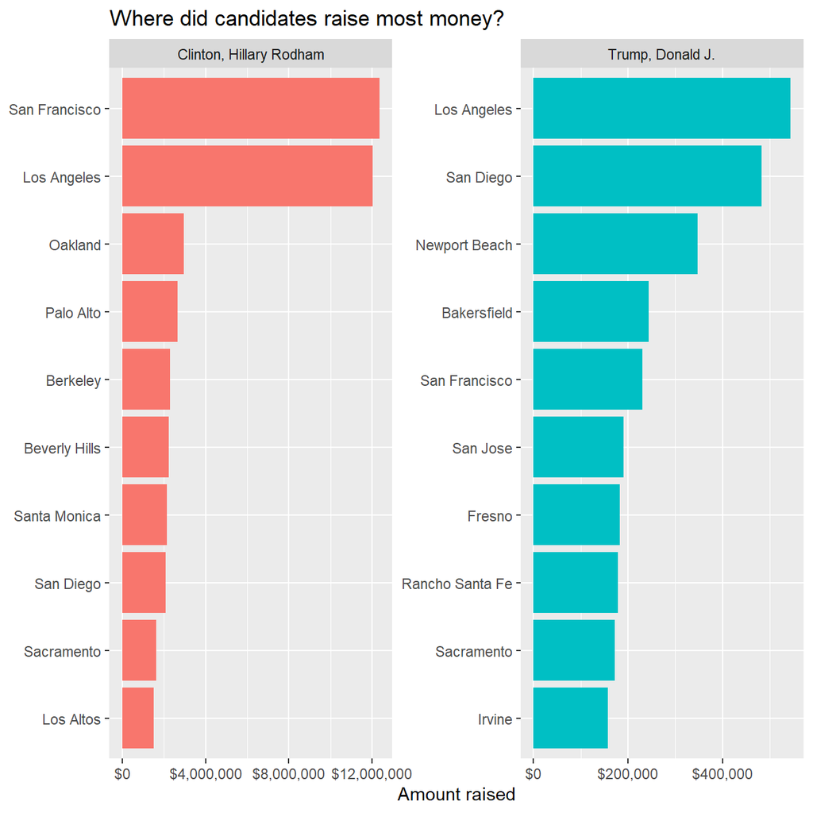

```r
# Make sure you use vroom() as it is significantly faster than read.csv()
library(patchwork)
library(tidytext)
CA_contributors_2016 <- vroom::vroom("CA_contributors_2016.csv")%>%
  mutate(zip = as.character(zip))

zip_codes <- vroom::vroom("zip_code_database.csv")%>%
  select(zip,primary_city)

top_candidates <- left_join(CA_contributors_2016,zip_codes)

top_candidates%>%
  group_by(cand_nm)%>%
  filter(cand_nm %in% c("Trump, Donald J.","Clinton, Hillary Rodham"))%>%
  group_by(cand_nm,primary_city)%>%
  summarise(city_donation=sum(contb_receipt_amt))%>%
  top_n(10)%>%
  mutate(cand_nm=as.factor(cand_nm), primary_city = reorder_within(primary_city,city_donation,cand_nm))%>%
  ggplot(aes(x=city_donation, y=primary_city, fill=cand_nm))+
  geom_col(show.legend = FALSE)+
  facet_wrap(~cand_nm,scales = "free")+
  scale_x_continuous(labels = scales::dollar_format())+
  scale_y_reordered()+
  labs(x = "Amount raised",
         y = NULL,
         title = "Where did candidates raise most money?")
```

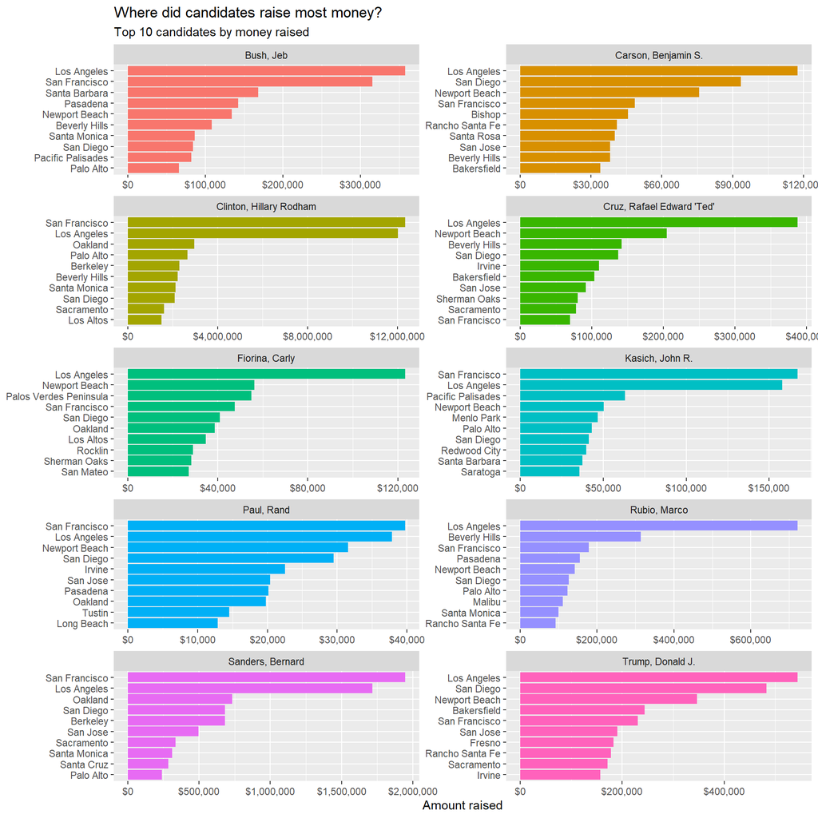

```r
top10_cand_name <- top_candidates%>%
  group_by(cand_nm)%>%
  summarise(cand_donation=sum(contb_receipt_amt))%>%
  arrange(desc(cand_donation))%>%
  top_n(10)

top10_cand_city <- left_join(top10_cand_name,top_candidates,"cand_nm")%>%
  group_by(cand_nm,primary_city)%>%
  summarise(city_donation=sum(contb_receipt_amt))%>%
  top_n(10)%>%
  mutate(cand_nm=as.factor(cand_nm), primary_city = reorder_within(primary_city,city_donation,cand_nm))%>%
  ggplot(aes(x=city_donation, y=primary_city, fill=cand_nm))+
  geom_col(show.legend = FALSE)+
  facet_wrap(~cand_nm,scales = "free", nrow = 5)+
  scale_x_continuous(labels = scales::dollar_format())+
  scale_y_reordered()+
  labs(x = "Amount raised",
         y = NULL,
         title = "Where did candidates raise most money?",
       subtitle = "Top 10 candidates by money raised")

  top10_cand_city
```

# 7 Details

- Who did you collaborate with: Shengwei Lai, Matias Pere, Philipp Permyakov, Sena Salman, Linda Wu, Alexander Pracht
- Approximately how much time did you spend on this problem set: n.a.
- What, if anything, gave you the most trouble: getting used to git hub